# R/Rstudio入門

## Quarto用語説明：コードチャンク

- Rを含むコードは，以下のようにコードチャンク内に記述する。

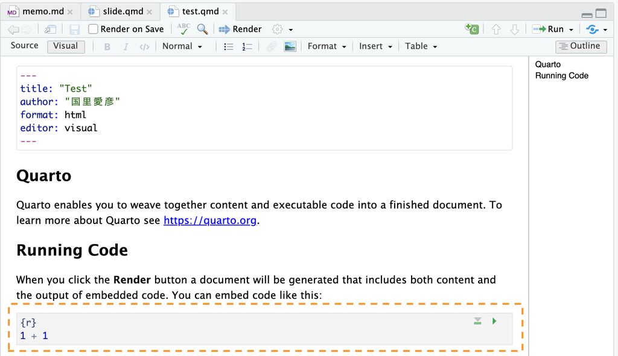

## Visual editorを使おう！

- Markdown記法はそれほど覚えることはない，文章中にコマンドのようなものが入ることに抵抗がある人もいるのでは（`**太字にしたい文字**`で太字に指定するなど，[Markdownの詳細はこちら](https://quarto.org/docs/authoring/markdown-basics.html)）
- Visual editorならWordに似たような操作感覚でMarkdown記法を覚えなくても文字の装飾ができる。

## 文字の装飾

- 太字にする場合は，太字にしたい文字を選択して，以下をクリックする。

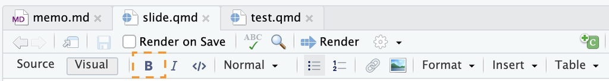

- 斜字にする場合は，斜字にしたい文字を選択して，以下をクリックする。

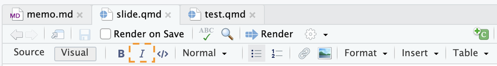

## コードのハイライト

- コードの説明をハイライトしたい（実行はしない）場合は，ハイライトしたい文字を選択して以下をクリックする。

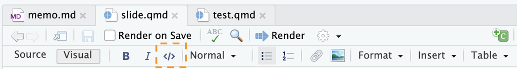

## 見出しでアウトラインを意識

- 普通の文章は`Normal`になり，見出しは`Header 1`から`Header 6`である。
- `Header` は数字が小さいほど，大きな見出しになる。
- 見出しを構造化して，文章のアウトラインを意識しよう！

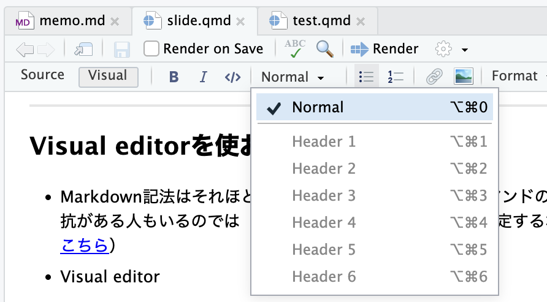

## 箇条書き

- 箇条書きする場合は，以下をクリックする。

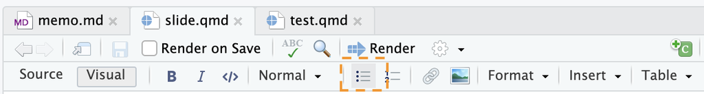

- 数字付きの箇条書きをする場合は，以下をクリックする。

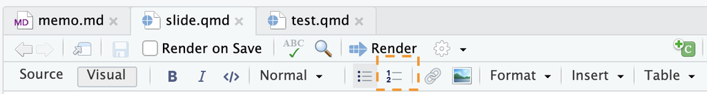

## リンクと画像の挿入

- リンクを挿入する場合，リンクを張りたいテキストを選んで，以下をクリックする。

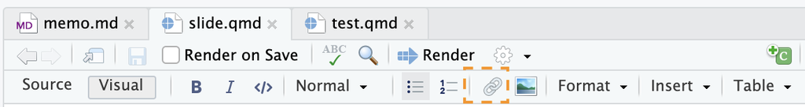

- URLにリンクを貼り付けて，`OK`をクリックする。

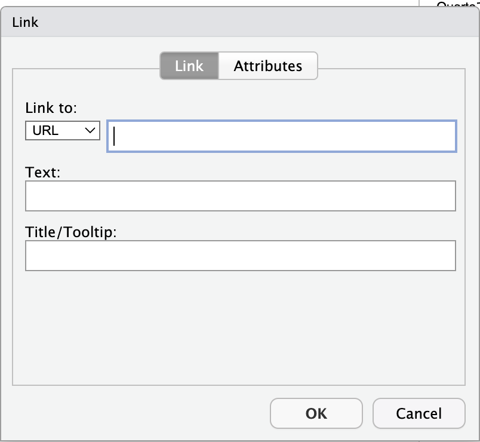

## 画像の挿入

- 画像を挿入したい箇所で以下をクリックする。

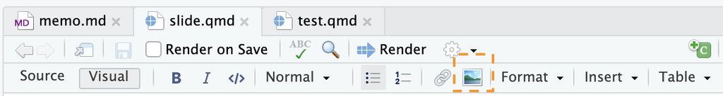

- 挿入したい画像を選択して，OKをクリックする（なお直接ドラッグ・アンド・ドロップも可）。

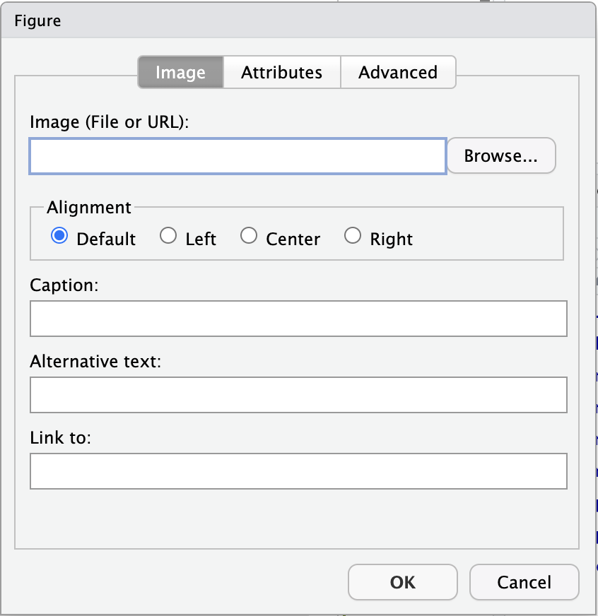

## ショートカットも便利

|  | キーボードショートカット | Markdown記法 |
| --- | --- | --- |
| ボールド体 | ⌘ B | `**bold**` |
| イタリック体 | ⌘ I | `*italic*` |
| コード | ⌘ D | `` `code` `` |
| 見出し 1 （一番大きい） | ⌥⌘ 1 | `#` |
| 見出し 2 | ⌥⌘ 2 | `##` |
| 見出し 3 | ⌥⌘ 3 | `###` |
| リンク | ⌘ K | `<href>` |
| Rチャンク | ⌥⌘ I | `` ```{r} `` |

## 文字の装飾

- Formatの右側のプルダウンからも他の種類の文字の装飾を選択できる（下線，上付き，下付き，取り消し線なども可能）。

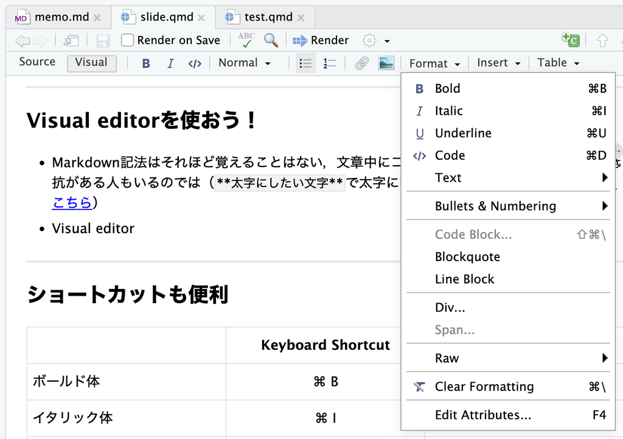

## Insert

- Insertのプルダウンメニューから様々な挿入ができる。

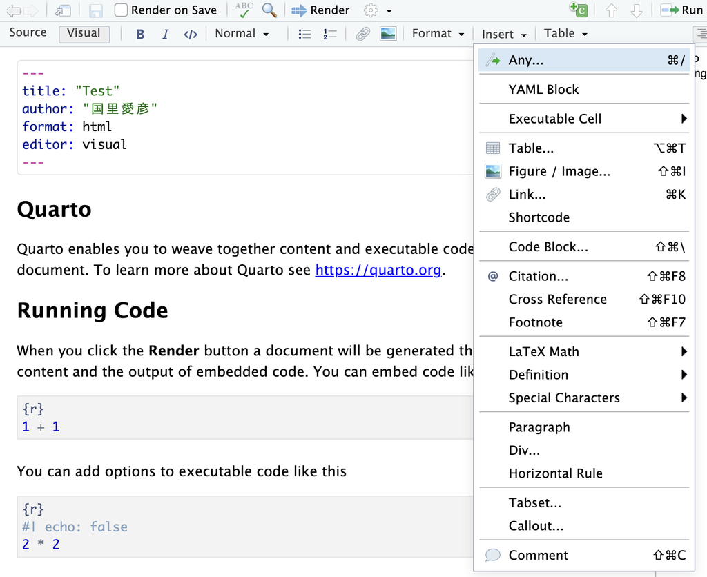

## Executable Cell

- Insert -> Executable Cellでコードチャンクを挿入できる（RからJuliaまで挿入可，MermaidとGraphVizはダイアグラムを描く，コードチャンクの詳細は後述）。

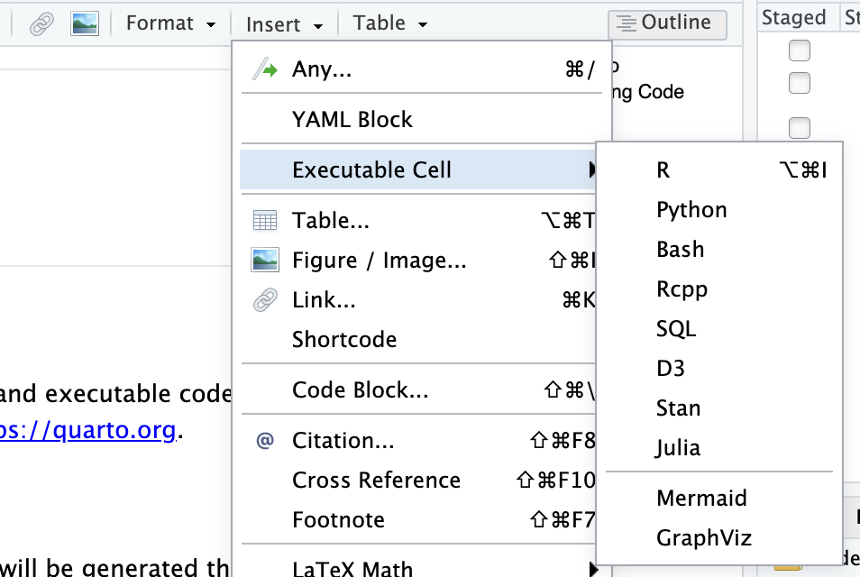

## MermaidとGraphviz

- MermaidとGraphvizは，ダイアグラムを描くソフトでQuartoで使える。
- SEMや因果ダイアグラムを描く時に便利（詳細[こちら](https://quarto.org/docs/authoring/diagrams.html)を参照）

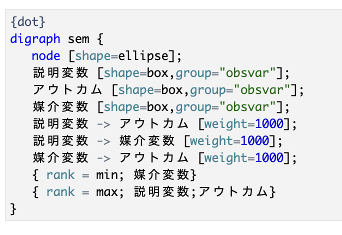

[figure not shown]

## 表，画像，リンク，動画などの挿入

- こちらのプルダウンメニューからも各種挿入ができる。

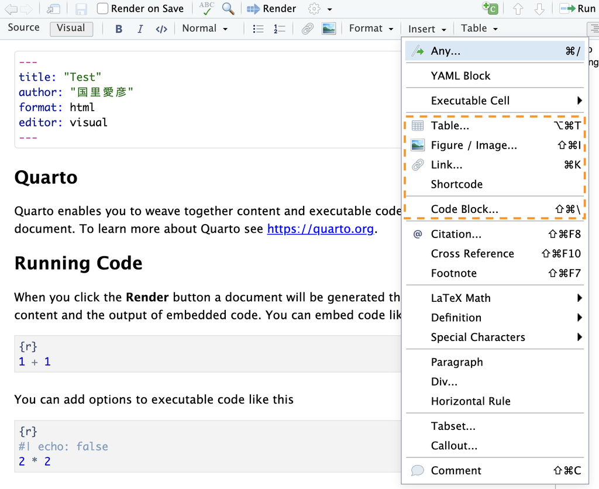

- Shortcodeは以下のように動画の挿入したり，WordやPDFでの改ページ(`pagebreak`)の指定ができる。

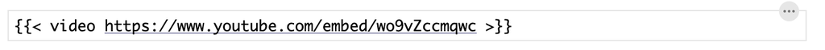

## 引用，相互参照，脚注

- Citationで文献の引用，Cross Referenceで図表や節などの相互参照，Footbnoteで脚注をいれることができる。

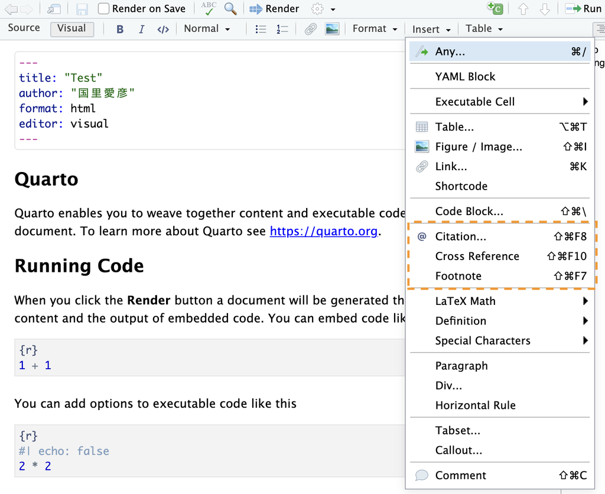

## 文献の引用

- Insert -> Citationで，以下の画面が立ち上がる。DOIやPubmed検索から文献を簡単に登録できる。
- 文献は`＠kunisato2023` だと`Kunisato et al.(2023)` となり，`[＠kunisato2023]` だと`(Kunisato et al., 2023)`となる。

[figure not shown]

## 数式，定義，特殊文字の挿入

- LaTeX MathでLatex形式で数式が挿入できる（文章内に挿入するInlineと数式だけの行をつくるDisplayがある）。
- 定義は用語説明に使えるが利便性が不明，特殊文字を入れたい場合はSpecial Charactersから挿入する。

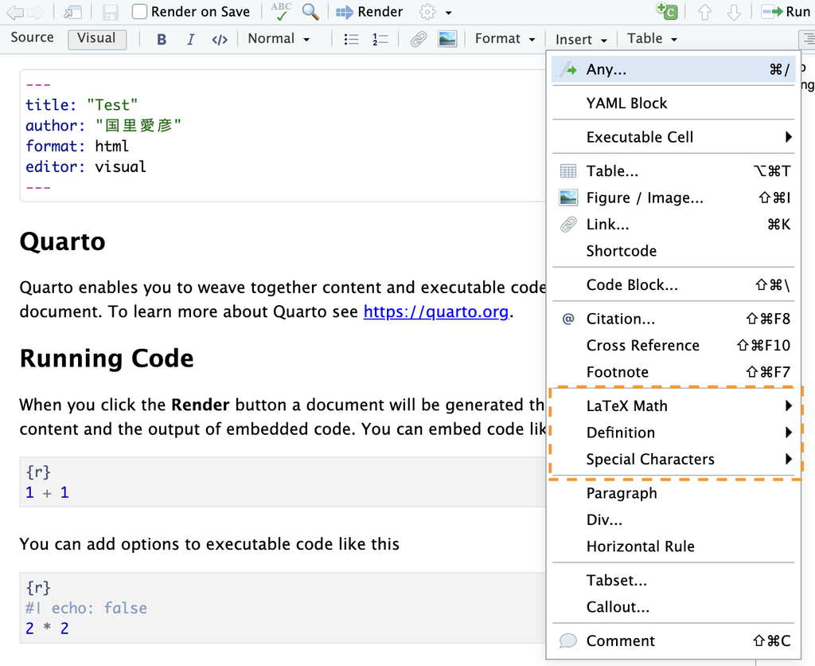

## パラグラフ，Div，水平線

- パラグラフ(p)とDivはHTMLで使われるものでHTMLで特殊な装飾をしたい場合に使える，Horizontal Ruleで水平線を入れられる。

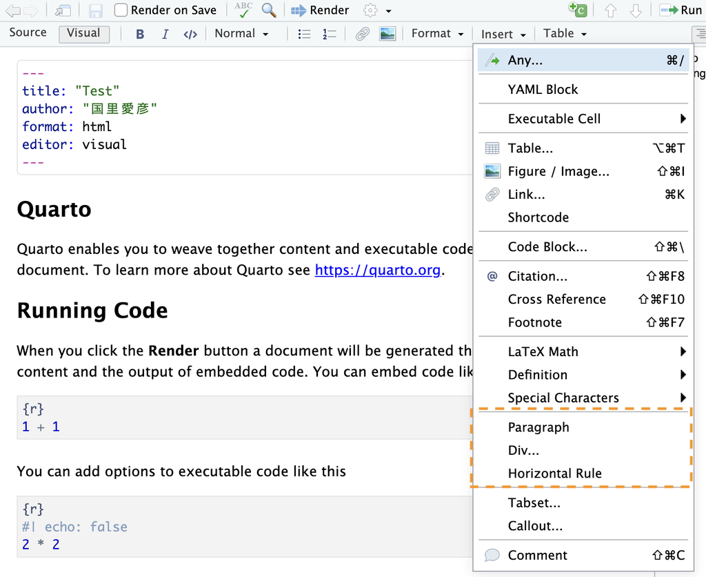

## タブ化，コールアウト

- Tabsetで文章やコードをタブ化でき，CalloutでTipsや警告などの表示を出すことができる。

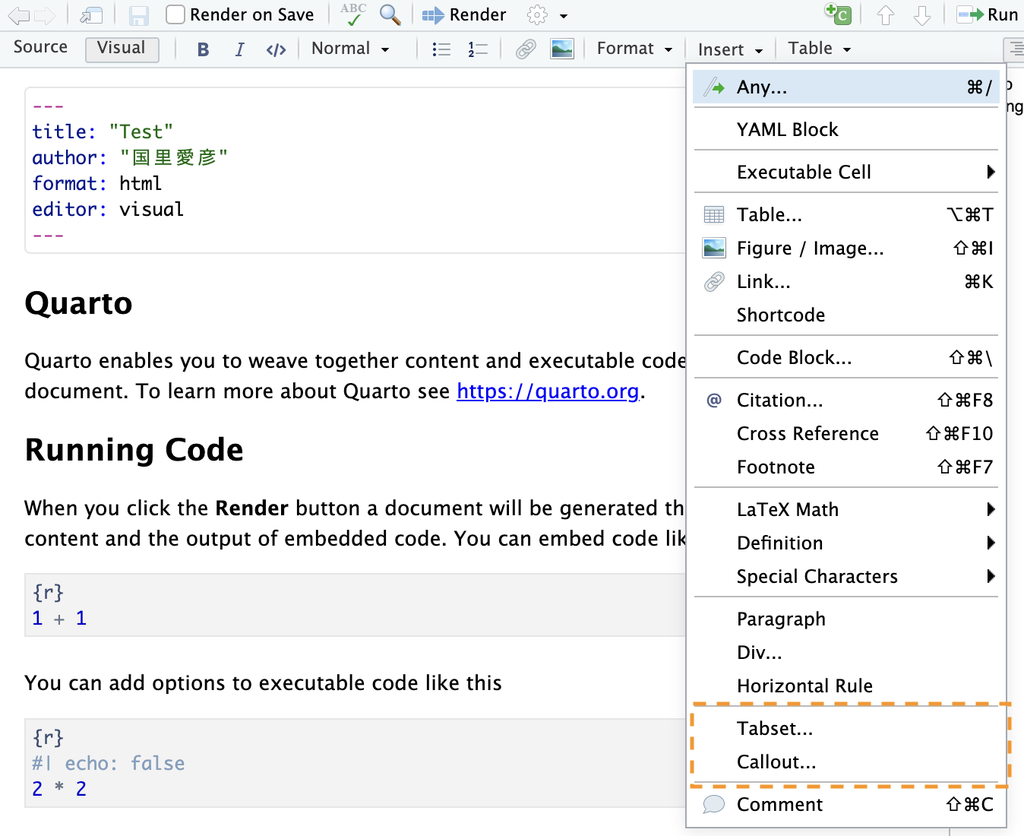

## タブ化

- Tabsetをクリックして，必要な数のタブ名を設定する。

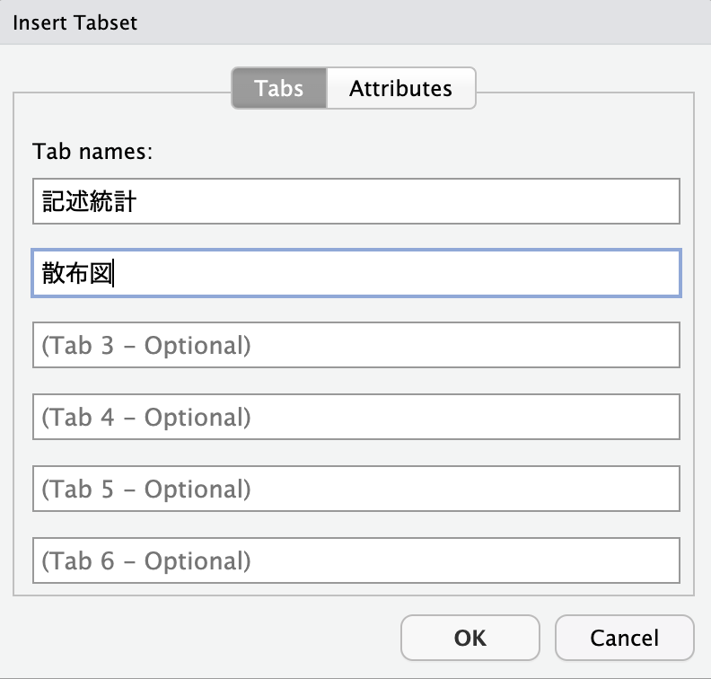

こんな感じになる。

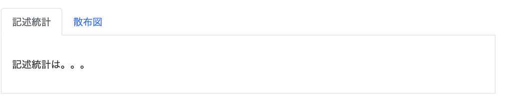

## コールアウト

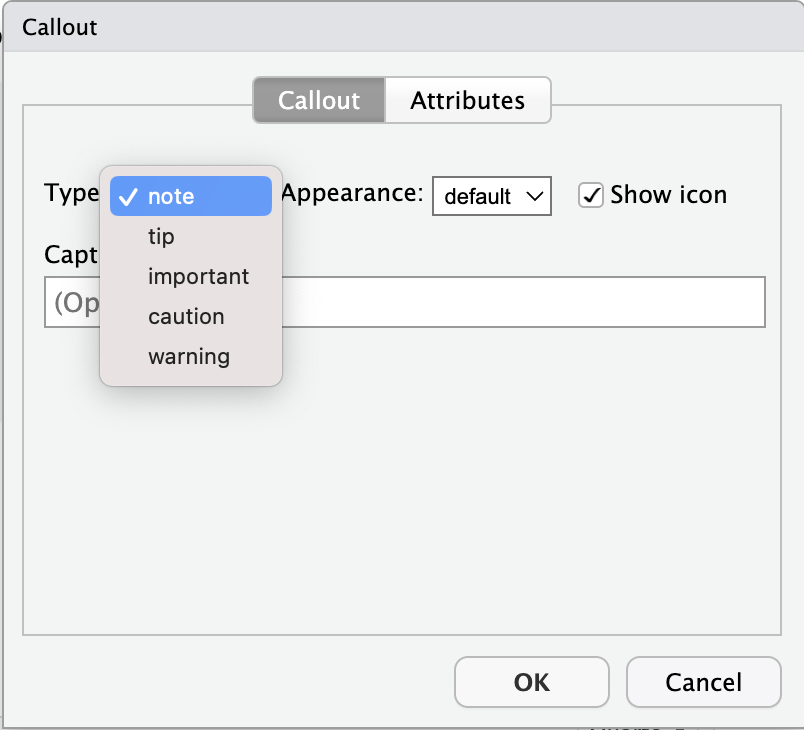

- 見た目をdefault, simple, minimalから１つ選ぶ。

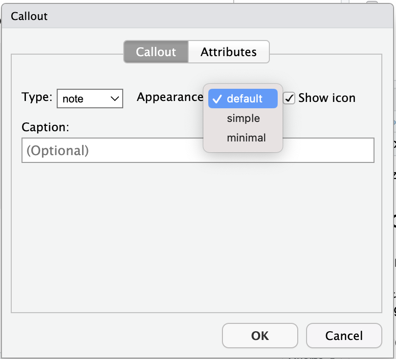

**Quartoの使い方（tip）**

Quartoの使い方としては・・・１つ目としては・・・

**Quartoの使い方(important)**

Quartoの使い方は・・・１つ目としては・・・

**Quartoの使い方(caution)**

Quartoの使い方は・・・１つ目としては・・・

**Quartoの使い方(warning)**

Quartoの使い方は・・・１つ目としてはデータ解析の報告書の作成がある・・・

**Quartoの使い方(warning,simple)**

Quartoの使い方は・・・１つ目としてはデータ解析の報告書の作成がある・・・

**Quartoの使い方(warning,minimal)**

Quartoの使い方は・・・１つ目としてはデータ解析の報告書の作成がある・・・

## コメント

- レポートには残したくないメモなどはコメントで残す。`＜！--# --＞`が挿入されるので，#より後ろにコメントを残す。

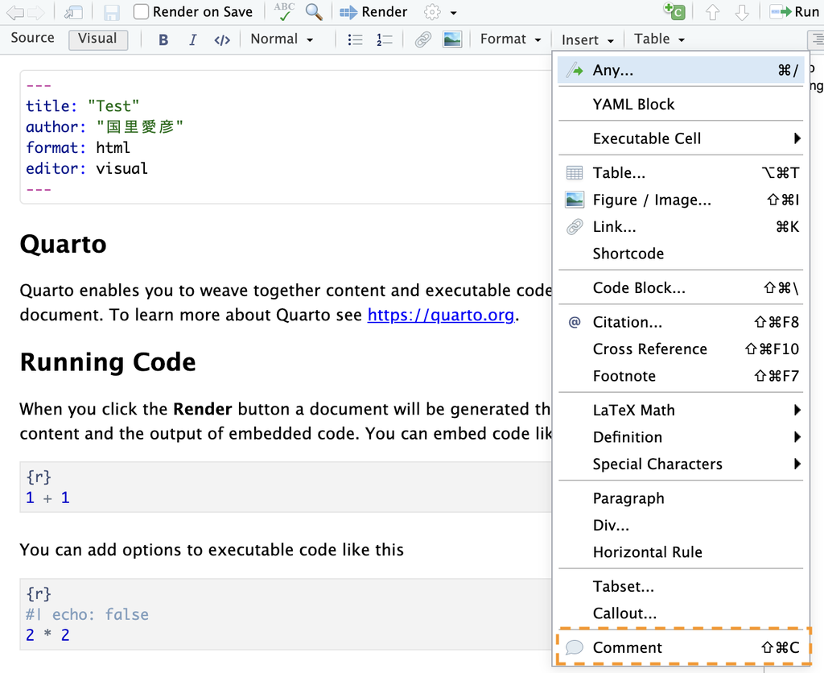

## 挿入のショートカット

- 挿入は，本文で`/` をタイプすることでも可能。

[figure not shown]

## 表の挿入

- TableのプルダウンメニューからInsert Tableをクリックする。

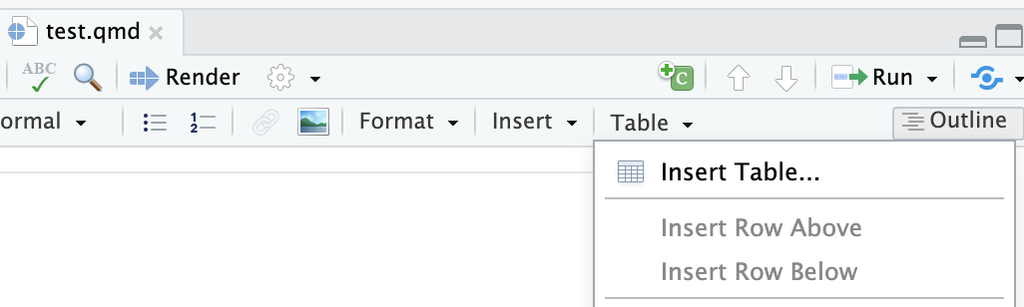

- 行数と列数を指定する。作った表を選択した状態でTableのプルダウンメニューを見ると表の変更が可能になる。

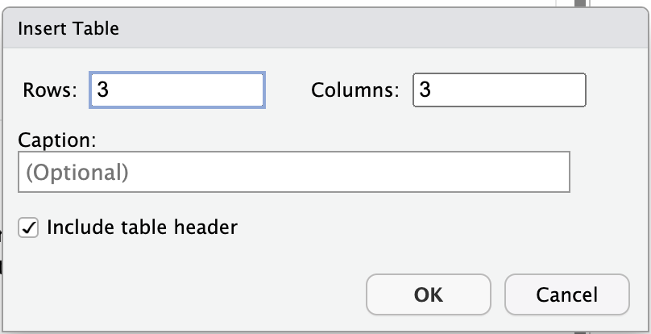

## チャンクオプション

- Rmdファイル内のRコードは，Rコードを表示する・しない，Rコードを実行する・しない，コードの結果を表示する・しないなど，色々と調整したいところ。
- Rチャンクには，オプションがあり，Rコードとその結果の扱いや図のサイズなどについても指定できる。
- Rコードのチャンクを参照するための名前をつける場合は，`label`を使う。

## チャンクオプション（Rコード）

| `eval` | コードの実行（`false`はコード表示のみ） |
| --- | --- |
| `echo` | コードの表示 |
| `output` | 実行した結果の表示（`true`, `false`, と `asis` 。 `asis` はmarkdownのままを出す場合） |
| `warning` | 警告の表示 |
| `error` | エラーの表示(エラーがでても処理継続) |
| `include` | コードと結果の表示(`false`ならすべての出力が抑制される) |

## チャンクオプション(figure)

| `fig-width` | 図の幅（単位はインチ） |
| --- | --- |
| `fig-height` | 図の高さ（単位はインチ） |
| `fig-cap` | 図のキャプション |
| `fig-subcap` | 図のサブキャプション |
| `out-width` | 出力されるドキュメントでの図の幅（図は出力先で調整されるのでfig-widthとは異なる。デフォルトはpxだが，cm, mm, in, inch, %の単位が使える） |
| `out-height` | 出力されるドキュメントでの図の高さ（図は出力先で調整されるのでfig-widthとは異なる。デフォルトはpxだが，cm, mm, in, inch, %の単位が使える） |

- コード表示，コード実行，結果表示の場合（out-でサイズも調整）

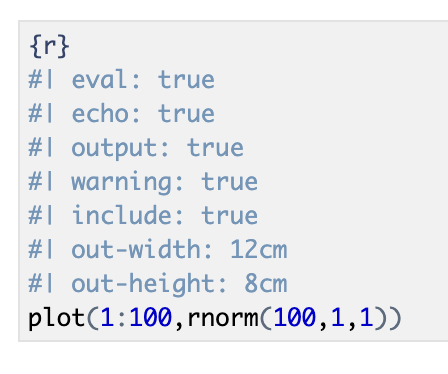

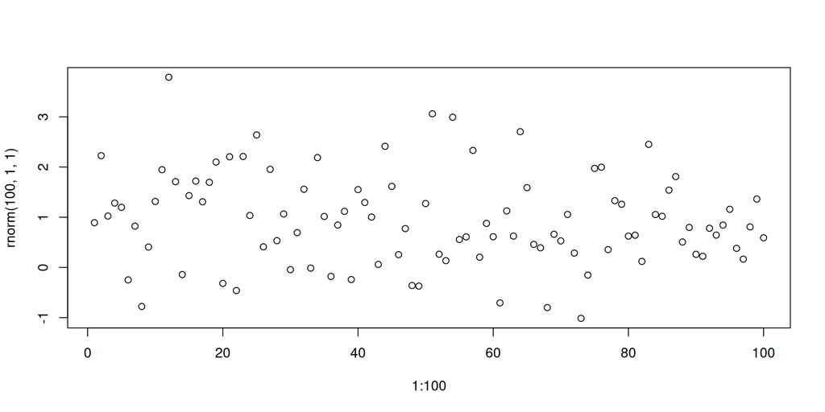

```r
plot(1:100,rnorm(100,1,1))
```

- コード表示しない，コード実行，結果表示

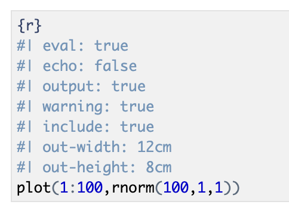

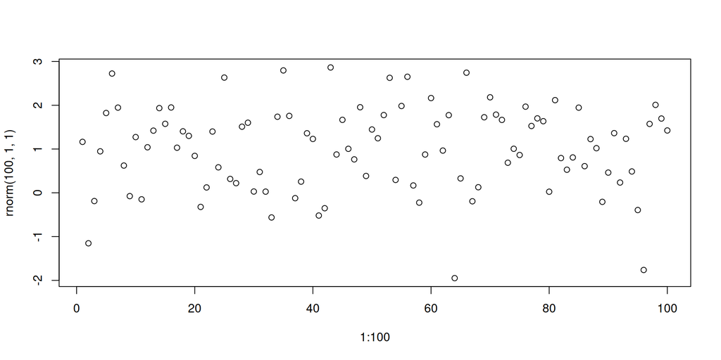

- コード表示，コード実行しない，結果も表示しない（できない）

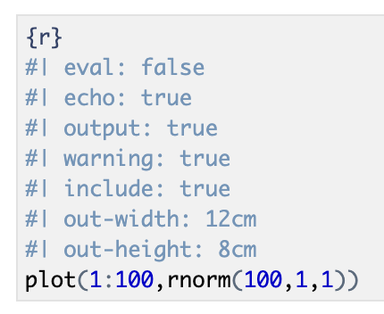

```r
plot(1:100,rnorm(100,1,1))
```

- チャンクオプションを駆使することで，ドキュメント内で必要なものだけを掲載できる。

# 演習

実際にqmdファイルを作って，データを読み込んで，Rのコードを実行してみましょう。

## Data Journal

データを掲載するジャーナルも増えてきている。

- [Journal of Open Psychology Data (JOPD)](https://openpsychologydata.metajnl.com/)
- [Scientific Data](https://www.nature.com/sdata/)
- [Data in Brief](https://www.sciencedirect.com/journal/data-in-brief)

## 今回使用するデータ

- 以下の論文のデータを使う。

[Woodworth, R. J., O’Brien-Malone, A., Diamond, M. R., & Schüz, B. (2018). Data from, “Web-based Positive Psychology Interventions: A Reexamination of Effectiveness.” *Journal of Open Psychology Data*. https://doi.org/10.5334/jopd.35](https://openpsychologydata.metajnl.com/articles/10.5334/jopd.35)

- データは以下のfigshareで公開されている。

https://figshare.com/articles/dataset/A_randomized_placebo-controlled_trial_of_positive_psychology_interventions_in_Australia/1577563/1

**対象者**：一般参加者295名

**介入**：３つのポジティブ心理学的介入と統制条件に無作為割付。(1)“Using Signature Strengths（ウェブサイトで性格の強みを評価し，上位の強みのうちの１つを次の週に新しい別のやり方で実施する）”，(2)“Three Good Things(その日に起こった良いことを３つあげて，なぜそれが起こったのか原因説明とともに記録する)”, (3)“Gratitude Visit(親切してくれたけど感謝を示してない人に手紙を書く介入)”,(4)“Recording early memories(統制条件，幼いころの記憶を書く)”

**アウトカム**：Authentic Happiness Inventory (AHI) の24項目，Center for Epidemiological Studies Depression(CES-D) scaleの20項目

**測定時期**：介入前(0), 介入後(1), 1週間後(2), １ヶ月後(3)，３ヶ月後(4)，６ヶ月後(5)

[Woodworth et al.(2018)のデータ](https://figshare.com/articles/dataset/A_randomized_placebo-controlled_trial_of_positive_psychology_interventions_in_Australia/1577563/1)にアクセスして，ファイルをダウンロードして開く。作成したプロジェクト内のdataフォルダ内にparticipant-info.csvとahi-cesd.csvを配置する。

[figure not shown]

### データの読み込み(qmdに書き込もう！)

- データの読み込み，データの前処理，可視化などはtidyverseパッケージ使うと便利。
- dataフォルダに保存したWoodworth et al.(2018)のデータを読み込む。データはcsv形式だったので，read_csv()で読み込む。ファイルはdataフォルダにいれているので，ファイル名の前に”data/“をいれる（フォルダを指定できる）。

```r
library("tidyverse")
participant <- read_csv("data/participant-info.csv")
data <- read_csv("data/ahi-cesd.csv")
```

## 動作確認

- qmdだと以下のような感じになる。Rチャンク右端の緑の三角形をクリックするとコードが実行されるので，クリックする。

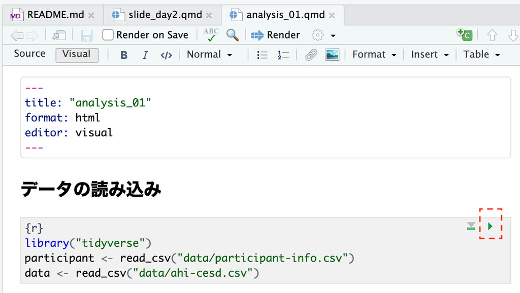

## データの確認

- コードを実行するとEnvironmentにオブジェクトが保存される。右端のアイコンをクリックするとオブジェクト（今回はデータ）を見ることができる。

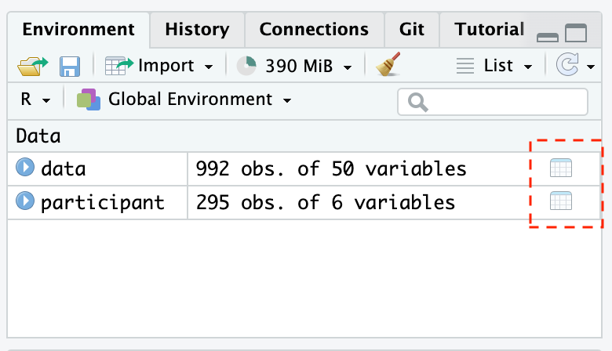

- participant-info.csvには，id, intervention, sex, age, educ, incomeのデータが入っている。

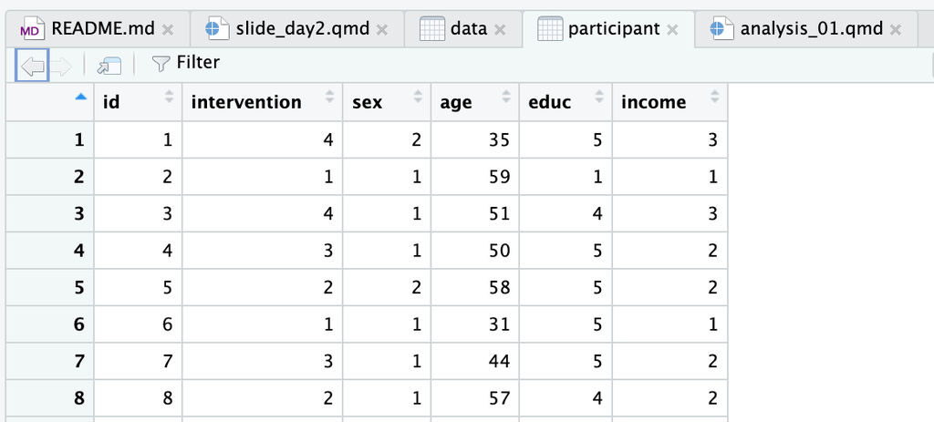

- ahi-cesd.csvには，id, occasion, elapsed.days, intervention, ahi01…などのデータが入っている。

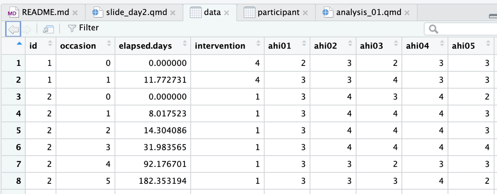

## データフレーム

- Rではデータフレームという構造でデータを扱う。データフレームは，a行b列からなる表形式のデータであり，列には変数が含まれる。
- read_csv()で読み込んだデータはデータフレームになっており，オブジェクト名を打つとデータフレームが表示される。

## データ型

- Rでの代表的なデータ型としては以下がある（read_csv()で読み込むと自動で判定をする）。

| データ型 | 説明 | 省略形 |
| --- | --- | --- |
| logical | 論理型（TRUE, FALSE） | lgl |
| integer | 整数型（1,2） | int |
| double | 倍精度小数点型 (1.0,2.1) | dbl |
| character | 文字型 | chr |
| factor | 因子型 | fct |
| ordered | 順序型 | ord |
| Date | 日付型 | date |

- パイプ演算子でつなぐと前の処理の内容が次の処理に引き継がれるので，可読性高くコードが書ける。
- `|>` はTools -> Global options -> Codeで，Use native pipe operator…にチェックをいれてApplyすればRStudioで使える。

[figure not shown]

Windowsは **Ctrl + Shift + m** Macは **Command + Shift + m**のショートカットでパイプ演算子が入力できる。

### 記述統計 (qmdに書き込もう！)

- 連続変数に関しては，summary()で必要な記述統計を出すことができる（selectで必要なものを選択すると便利）。

```r
participant |>
  select(age, educ, income) |>
  summary()
```

```
      age             educ          income
 Min.   :18.00   Min.   :1.00   Min.   :1.000
 1st Qu.:34.00   1st Qu.:3.50   1st Qu.:2.000
 Median :44.00   Median :4.00   Median :2.000
 Mean   :43.76   Mean   :3.98   Mean   :2.044
 3rd Qu.:52.00   3rd Qu.:5.00   3rd Qu.:3.000
 Max.   :83.00   Max.   :5.00   Max.   :3.000
```

### クロス集計(qmdに書き込もう！)

- 質的変数の場合は，table()でクロス集計を出すことができる。selectで性別絞ってクロス集計を出すと，女性が多いことが分かる。

```r
participant |>
  select(sex) |>
  table()
```

```
sex
  1   2
251  44
```

### 記述統計の要約表(qmdに書き込もう！)

- `gtsummary` パッケージの`tbl_summary()`を使うと簡単に変数の要約ができる(`by`でグループ分けして表にできる）
- gtsummary()の調整法としては，[こちら](https://note.com/mitti1210/n/n8aa3333588f2)が参考になる。

```r
library(gtsummary)
participant |>
  select(-id) |>
  tbl_summary(by = intervention)
```

| **Characteristic** | **1** N = 72<sup>1</sup> | **2** N = 76<sup>1</sup> | **3** N = 74<sup>1</sup> | **4** N = 73<sup>1</sup> |
| --- | --- | --- | --- | --- |
| sex |  |  |  |  |
| 1 | 62 (86%) | 66 (87%) | 62 (84%) | 61 (84%) |
| 2 | 10 (14%) | 10 (13%) | 12 (16%) | 12 (16%) |
| age | 45 (36, 55) | 46 (36, 54) | 44 (34, 51) | 40 (32, 51) |
| educ |  |  |  |  |
| 1 | 3 (4.2%) | 3 (3.9%) | 2 (2.7%) | 6 (8.2%) |
| 2 | 3 (4.2%) | 8 (11%) | 3 (4.1%) | 7 (9.6%) |
| 3 | 10 (14%) | 7 (9.2%) | 7 (9.5%) | 15 (21%) |
| 4 | 26 (36%) | 32 (42%) | 32 (43%) | 14 (19%) |
| 5 | 30 (42%) | 26 (34%) | 30 (41%) | 31 (42%) |
| income |  |  |  |  |
| 1 | 21 (29%) | 20 (26%) | 17 (23%) | 15 (21%) |
| 2 | 31 (43%) | 34 (45%) | 36 (49%) | 35 (48%) |
| 3 | 20 (28%) | 22 (29%) | 21 (28%) | 23 (32%) |

<sup>1</sup> n (%); Median (Q1, Q3)

## ggplot2で可視化しよう！

- データの可視化は，(1)データに対する前処理が適切にできているかチェック，(2)データの測定法が適切にできているかチェック，(3)データの傾向をチェック，(4)データに適用する統計手法が適切かチェックするために行う。
- Rのggplot2パッケージがきれいに図が作成できて，コードも読みやすく書ける。
- ggplot2は，グラフィックの文法 (**g**rammar of **g**raphics)という思想の元に作成されている。これは，有る決まった構造で作成されたレイヤーを重ねていって図を作成するという考え方。

### ヒストグラム(qmdに書き込もう！)

- 量的な変数はヒストグラムで分布を確認
- occasion=0のCES-D得点のヒストグラムを描く。filterでoccasion=0に絞り込んで，パイプ演算子でfilterされたdataをggplotに入れて，aesでx軸を指定する。

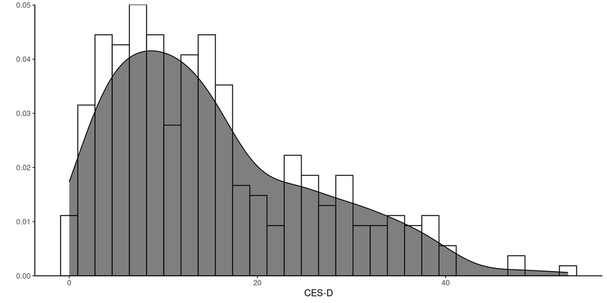

```r
data |>
  filter(occasion == 0) |>
  ggplot(aes(x=cesdTotal)) +
  geom_histogram(aes(y=after_stat(density)),fill='white', color='black') +
  geom_density(fill='black', alpha = 0.5) +
  theme_classic() +
  scale_y_continuous(expand=c(0,0)) +
  labs(x = "CES-D", y="")
```

- geom_histogram()でヒストグラムが描けるが，theme_classic()にしたり，グラフが浮かないようにしたり，x軸のラベルを変えたり調整。密度プロット（density plot）も追加する。

### レインクラウド(qmdに書き込もう！)

- 箱ひげ図，バイオリンプロット，ドットプロットを組み合わせたものとして，レインクラウドプロットがある。ggdistパッケージで描ける。
- `stat_halfeye()`でバイオリンプロットの半分を描いてから，`stat_dots`でドットプロット追加し，`geom_boxplot`で箱ひげ図を追加する。

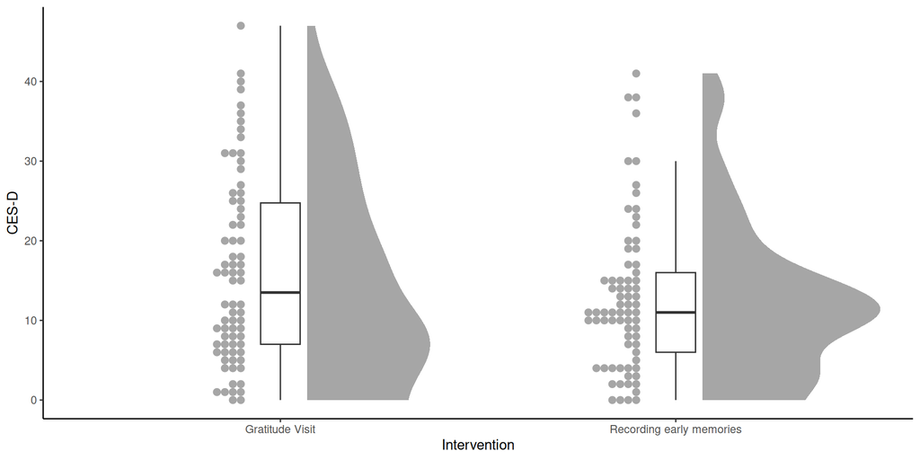

```r
library(ggdist)
data |>
  filter(intervention == 3 | intervention == 4) |>
  filter(occasion == 0) |>
  mutate(intervention2 = ifelse(intervention == 3,"Gratitude Visit","Recording early memories")) |>
  ggplot(aes(x = intervention2, y = cesdTotal)) +
  stat_halfeye(width = .5, justification = -.15,point_color = NA, .width = 0) +
  stat_dots(side = "left", dotsize = 1, justification = 1.1, binwidth = 1) +
  geom_boxplot(width = .1,outlier.shape = NA) +
  theme_classic() +
  labs(x = "Intervention", y = "CES-D") +
  coord_cartesian(clip = 'off', xlim = c(1, 2))
```

## HTMLを共有する際の工夫

- HTMLファイルは便利ですが，他の人と共有する際に，画像などの各種ファイルも同時に共有する必要がある（面倒だし，メールで送れない）。
- qmdファイルのYAMLの”format: html”を以下に変更するとHTMLファイルに画像などを埋め込んでくれる。

```
format:
  html:
    embed-resources: true
    toc: true
    toc-depth: 2
```

## Quartoを日常使いしよう！

- 可視化までしか扱ってないが，基本的な Quartoドキュメントの使い方は変わらない。文章を書いて，適宜装飾し，Rコードを実行し，適宜チャンクオプションで指定する。
- 今回省略した前処理と可視化の詳細はこちらを[参照](https://ykunisato.github.io/ccp-lab-slide/tws-quarto-2023/tidyverse.html)ください。

## 解析報告書以外の活用法

- プレゼンテーションスライド
- ウェブサイト
- 本
- 論文

## プレゼンテーション

- Quartoでプレゼンスライドも作れる（このスライドもQuartoで作成している）。
- Rの解析結果が含まれるような研究の場合は，Quartoで作成するのも便利（変にスライドにこだわらなくなるのも良い）
- 作成法：新規作成からQuarto Presentationを選択して，`revealjs` (reveal.js, HTML), `pptx` (MS Power Point), `beamer` (Beamer, LaTeX/PDF)の３つから１つを選ぶ。

[figure not shown]

## ウェブサイト

- File -> New Project…-> New DirectoryでQuarto Websiteを選ぶ。
- 既にあるqmdファイルに加筆し，新規作成したqmdファイルを`_quarto.yml` に追加するなどしてウェブサイトを作る。
- BuildのRender Websiteでウェブサイト全体のRenderを行う。

[figure not shown]

## 本

[figure not shown]

# Quartoを使った論文執筆方法

## Quartoの学術雑誌テンプレート

- [Quarto Journal Templates](https://github.com/quarto-journals/)には，複数のジャーナル/出版社用のテンプレートが用意されている。

| Journal / Publisher | Name | Install |
| --- | --- | --- |
| Association of Computing Machinery | acm | `quarto use template quarto-journals/acm` |
| American Chemical Society | acs | `quarto use template quarto-journals/acs` |
| American Geophysical Union | agu | `quarto use template quarto-journals/agu` |
| Biophysical journal | biophysical-journal | `quarto use template quarto-journals/biophysical-journal` |
| Elsevier Journals | elsevier | `quarto use template quarto-journals/elsevier` |
| American Statistical Association Journals | jasa | `quarto use template quarto-journals/jasa` |
| Journal of Statistical Software | jss | `quarto use template quarto-journals/jss` |
| Public Library of Science | plos | `quarto use template quarto-journals/plos` |

## Quarto Journal Templatesを使う

- RStudioのTerminalタブにQuarto Journal Templatesから選んだジャーナル/出版社のInstallコマンドを貼り付ける（なお，事前にカレントワーキングディレクトリを確認する）。

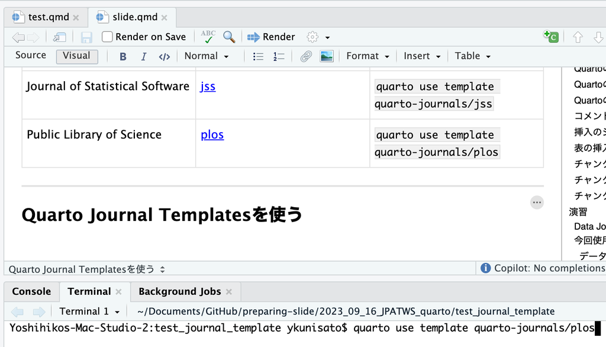

## Quarto Journal Templatesのインストール

- 「Do you trust the authors of this template」に`Y`，「Directory name:」に好きなディレクトリ名をつける（ただし，英数字で名前をつける）

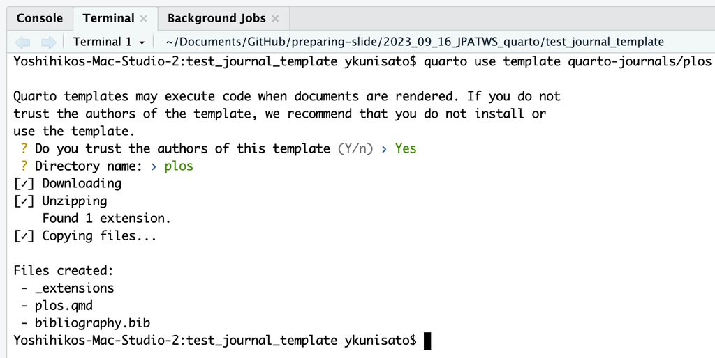

## PLOS ONEテンプレート

- PLOS ONE用のテンプレートのqmdファイルを開く。
- 本来は自分用に改変をするが，まずはRenderする。

[figure not shown]

## PLOS ONEテンプレートの出力

- PDF形式で美しく出力される。

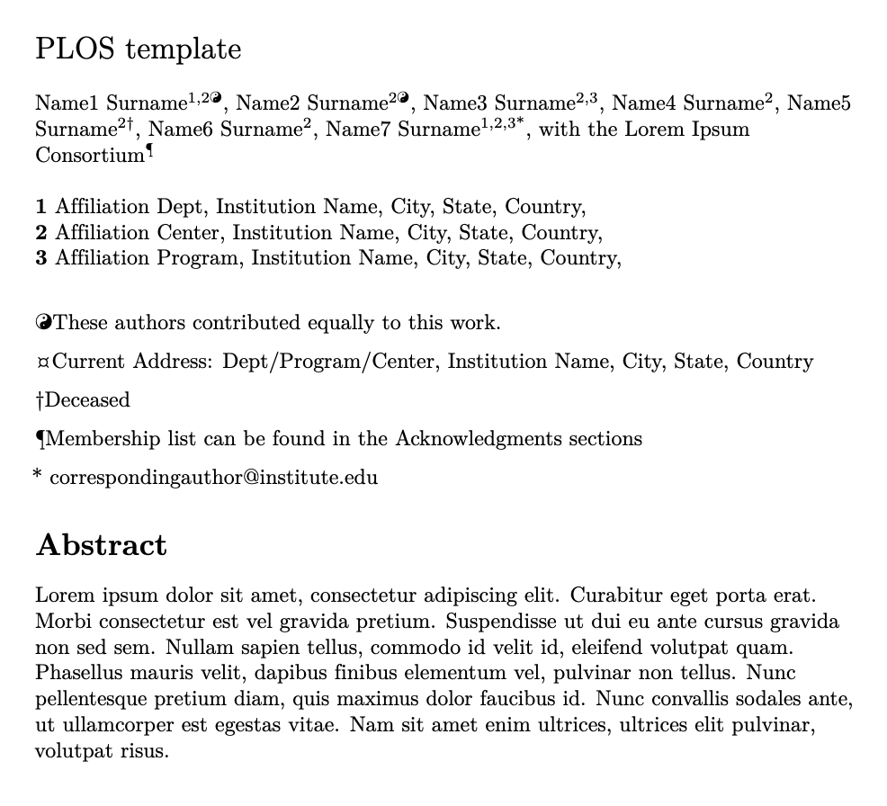

### A Quarto Extension for Creating APA 7 Style Documents

- [Quarto Journal Templates](https://github.com/quarto-journals/)には登録されていないが，APA形式での出力ができるテンプレートもある。
- [A Quarto Extension for Creating APA 7 Style Documents](https://github.com/wjschne/apaquarto)にあるように，以下をRStudioのTerminal上で実行すれば，APA形式のテンプレートが入手できる。

```
quarto use template wjschne/apaquarto
```

## オリジナルテンプレート作成

- [Quarto Journal Templates](https://github.com/quarto-journals/)にない場合は，自分でオリジナルテンプレートを作成する（共有すれば他の人も使える）。
- オリジナルテンプレートを作成する場合，[Githubのarticle-format-template](https://github.com/quarto-journals/article-format-template)をコピーして使うのが良さそう。

## jpaRmd

- jpaRmdは，R Markdownで論文を書くためのテンプレートパッケージ。
- 心理学研究などに投稿可能な形式で美しいPDFが出力される([Kosugitti](https://twitter.com/kosugitti)のいぶし銀Rコードにより完璧な引用文献リストが作成できる！）。

→困る点：共著者や英文校閲者がwordのコメント機能を使うとなるとPDFが不便，LaTeXベースなので美しさを重視して行数が投稿規定からずれることがある，最終的に出版社からwordを求められる…wordに変換する時チョット泣いた…

## 完璧なものより使えるものを

- PDFで美的なフォーマットにこだわるのをやめる!
- 最近は雑誌/出版社がWordテンプレートを出していたりするので，Wordテンプレートに合わせてWordを出力するようにしたい。

### [Japanese Psychological Research](https://psych.or.jp/publication/jpr/)用テンプレート

- JPRは便利なWordテンプレートが共有されているし，私がAssociate Editorでもあるので，試しに[Quarto Journal Templates](https://github.com/quarto-journals/)に従って作成してみました。
- 作成したテンプレートは，https://github.com/ykunisato/jprにあります。

## JPRテンプレートの使い方

- RStudioのTerminalで以下を打ち込む。

```
quarto use template ykunisato/jpr
```

- “jpr_paper.qmd”を開いて，適宜書き込む（学会が提供するWord Templateのコメントも追加しているので参照ください）。
- Renderをクリックして，Word出力して確認する。

なお，心理学研究用のテンプレートのjjpも作成している。

### オリジナルテンプレートを作る方法(1)：マニア用

GitHubアカウントを作成して，https://github.com/quarto-journals/article-format-template にアクセスする。

[figure not shown]

### オリジナルテンプレートを作る方法(2)：マニア用

- 「Create a new repository」をクリックする。

[figure not shown]

### オリジナルテンプレートを作る方法(3)：マニア用

- Repository nemeを指定し，「Create repository」をクリックする。
- 出力によって変わるが，テンプレートのqmdファイルやbibファイルなどを用意してGithubにアップロードすると利用可能になる。

[figure not shown]

## senshuQmd

[figure not shown]

## senshuQmdの使い方

- [Githubリポジトリ](https://github.com/ykunisato/senshuQmd)
- ターミナルで設定する場合

```
quarto use template ykunisato/senshuQmd
```

- Rで設定する場合(psyinfrパッケージを使う)

```
remotes::install_github("ykunisato/psyinfr")}
psyinfr::add_paperQmd()
```

## japQmd

[figure not shown]

## jpaQmdの使い方

- [Githubリポジトリ](https://github.com/ykunisato/jpaQmd)
- ターミナルで設定する場合

```
quarto use template ykunisato/jpaQmd
```

- Rで設定する場合(psyinfrパッケージを使う)

```
remotes::install_github("ykunisato/psyinfr")}
psyinfr::add_jpaQmd()
```

## Qmd化して良かったこと

- ゼロからテンプレートを作ったので，latexのテンプレがめちゃくちゃシンプルになった（改変可能）
- 引用文献の処理をbiblatex-jpaに投げることができたのと，処理としてもスムーズに
- RmarkdownのテンプレよりもQmdのテンプレの方が簡単に作れる（psyinfrの処理もGithubからファイルをダウンロードしてちょっと整理するだけ）

## 引用文献

Baker, Monya. 2015. “Over Half of Psychology Studies Fail Reproducibility Test.” *Nature*, August.

Goodman, Steven N, Daniele Fanelli, and John P A Ioannidis. 2016. “What Does Research Reproducibility Mean?” *Science Translational Medicine* 8 (341): 341ps12.

Ioannidis, John P A. 2005. “Contradicted and Initially Stronger Effects in Highly Cited Clinical Research.” *JAMA: The Journal of the American Medical Association* 294 (2): 218–28.

Iqbal, Shareen A, Joshua D Wallach, Muin J Khoury, Sheri D Schully, and John P A Ioannidis. 2016. “Reproducible Research Practices and Transparency Across the Biomedical Literature.” *PLoS Biology* 14 (1): e1002333.

Open Science Collaboration. 2015. “PSYCHOLOGY. Estimating the Reproducibility of Psychological Science.” *Science (New York, N.Y.)* 349 (6251): aac4716.

Stodden, Victoria, Jennifer Seiler, and Zhaokun Ma. 2018. “An Empirical Analysis of Journal Policy Effectiveness for Computational Reproducibility.” *Proceedings of the National Academy of Sciences of the United States of America* 115 (11): 2584–89.

Wallach, Joshua D, Kevin W Boyack, and John P A Ioannidis. 2018. “Reproducible Research Practices, Transparency, and Open Access Data in the Biomedical Literature, 2015-2017.” *PLoS Biology* 16 (11): e2006930.